# Session 2: Intro to frequentist models in R

Natalie Z. Kerr & Brian Lovett

October 11, 2020

## Workshop description

Here, we will cover how to run linear models (LMs; e.g., Gaussian/Normal distribution), generalized linear models (GLMs; e.g., binomial, Poisson for count data), and mixed models (LMMs/GLMMs; e.g., fixed vs. random effects). We will also expand on models using Poisson-distributed data by evaluating how to deal with common issues such as when your count data are over-dispersed/under-dispersed (e.g., Poisson vs. Negative Binomial vs. Conway-Maxwell-Poisson), when counts should be represented as rates (e.g., counts per unit time using Poisson offsets), and when your count data are zero-inflated (e.g., 0-inflated regression vs hurdle models). Finally, we will finish the session on appropriate ways to run model selection techniques for finding a winning model from a set of candidate models, using likelihood ratio tests for nested models and Akaike Information Criteria (AIC). This course will not be a statistics course, so people will need to be familiar with most of these models.

## Packages required

Before running the following code, please open the R Project for the EntSoc R Webinar series in the main folder (“EntSoc_R-Webinar_2020.Rproj”).

Here, is a list of packages required for this R course. You will need to install these prior to the class, either install from the “packages” panel in R studio or using the function below.

> install.package("")

Once installed, we can run these packages in advance. I will inform you whenever we are running a function from each of these packages throughout this session.

```r
library(here) # for navigation among folders
library(tidyverse) # for all tidyverse packages

library(pscl) # for zero-inflated regression models
library(glmmTMB) # for hurdle models
library(lme4) # for mixed models

library(car) # for likelihood ratio tests/marginal hypothesis testing
library(lmtest) # for likelihood ratio tests
library(bbmle) # for AIC
```

## Workshop topics

Today, we will cover five main topics in this workshop:

1. Linear models
2. Model selection approaches
3. Generalized linear models
4. Common issues with Poisson-distributed data
5. Mixed models

We will cover alternative statistical distributions to the Normal and Poisson distributions, when encountering common issues with these data. For background reading that is required for this course, I would highly recommend reading:

- “Ecological models and data in R” by *Ben Bolker*
- “Model Selection and Inference: A Practical Information-Theoretic Approach” by *Kenneth Burnham* and *David Anderson*
- Some of the first chapters (1-6) of “Program MARK: A Gentle Introduction” by *Gary White* and *Evan Cooch* that provides a good introduction to probability maximum likelihood estimation.

I have listed some other useful resources at the end of this rmarkdown file. Many of my example datasets were used in “Introduction to WinBUgS for Ecologists” by *Marc Kery* that provides both WinBUGS and R code.

### 1. Intro to linear models

First, we will cover running linear models (LMs) for normally-distributed (or Gaussian distributed) data. Linear models can be used to carry out single stratum analysis of variance (i.e., intercept-only models), analysis of variance (ANOVA, i.e., differences among groups), regression, and analysis of covariance (ANCOVA).

For these models, we will use Brown hare (*Lepus europaeus*) data over 17 years (1992-2008) at 56 sites in 8 regions of Switzerland for most of our examples today. Sites vary in area, elevation, and belong to two habitat types (arable and grassland). Mean density is the count1 of hares offset by the area of the site (i.e., mean.density = count1/area). These data are used in the [2010 Marc Kery book](https://www.mbr-pwrc.usgs.gov/software/kerybook/) that contains examples of both R and WinBUGS code.

```r
hares <- read.table(here::here("Session 2", "Data", "hares.txt"), header = T)
head(hares)
```

```
##   no site     region area elevation landuse year count1 count2 mean.density
## 1  1 AG01 CH.Central 2.23       384  arable 1992     NA     NA           NA
## 2  2 AG01 CH.Central 2.23       384  arable 1993     NA     NA           NA
## 3  3 AG01 CH.Central 2.23       384  arable 1994     NA     NA           NA
## 4  4 AG01 CH.Central 2.23       384  arable 1995      6      4     2.690583
## 5  5 AG01 CH.Central 2.23       384  arable 1996      7      5     3.139013
## 6  6 AG01 CH.Central 2.23       384  arable 1997      3      3     1.345291
```

#### Intercept-only models

First, we will run a single stratum analysis of variance (aka “intercept-only”) model to estimate the mean density of Brown hares across Switzerland.

```r
dens1 <- lm(mean.density ~ 1, data = hares)
summary(dens1)
```

```
##
## Call:
## lm(formula = mean.density ~ 1, data = hares)
##
## Residuals:
##     Min      1Q  Median      3Q     Max
## -4.6137 -2.7488 -0.9541  1.5672 17.3565
##
## Coefficients:
##             Estimate Std. Error t value Pr(>|t|)
## (Intercept)   4.7366     0.1467   32.29   <2e-16 ***
## ---
## Signif. codes:  0 '***' 0.001 '**' 0.01 '*' 0.05 '.' 0.1 ' ' 1
##
## Residual standard error: 3.817 on 676 degrees of freedom
##   (275 observations deleted due to missingness)
```

Interpreting the summary output:

- *Call:* model formula.
- *Residuals:* difference between the observed response values and model predicted values. Mean should be zero.
- *Coefficients:*
  - Model estimate
  - SE of model estimate
  - t-value (SDs our estimate is from 0)
  - P-value (i.e., probability of observing a value equal or larger than *t*, i.e., is our model estimate is significantly different from 0?)
- *Residual Standard Error:* average amount that the response will deviate from our model estimate.

```r
mean(dens1$residuals) # mean of the residuals is close to zero
```

```
## [1] 4.079368e-16
```

```r
mean(hares$mean.density, na.rm = T) # Mean
```

```
## [1] 4.736569
```

```r
sd(hares$mean.density, na.rm = T)/sqrt(nrow(subset(hares, !is.na(mean.density)))) # SE = sd/sqrt(n)
```

```
## [1] 0.1466952
```

```r
summary(dens1)$sigma / summary(dens1)$coefficient[1] # 80% percentage error
```

```
## [1] 0.8058354
```

#### One-way ANOVA

Here, we will run a one-way analysis of variance (ANOVA) model to estimate mean density of brown hares in the two habitat types: arable vs. grassland.

```r
dens2 <- lm(mean.density ~ landuse, data = hares)
summary(dens2)
```

```
##
## Call:
## lm(formula = mean.density ~ landuse, data = hares)
##
## Residuals:
##     Min      1Q  Median      3Q     Max
## -5.1593 -2.6117 -0.9307  1.7159 16.7613
##
## Coefficients:
##              Estimate Std. Error t value Pr(>|t|)
## (Intercept)    5.3317     0.1672  31.893  < 2e-16 ***
## landusegrass  -2.1432     0.3172  -6.756 3.07e-11 ***
## ---
## Signif. codes:  0 '***' 0.001 '**' 0.01 '*' 0.05 '.' 0.1 ' ' 1
##
## Residual standard error: 3.697 on 675 degrees of freedom
##   (275 observations deleted due to missingness)
## Multiple R-squared:  0.06333,    Adjusted R-squared:  0.06194
## F-statistic: 45.64 on 1 and 675 DF,  p-value: 3.072e-11
```

The lm() summary also contains three more outputs:

- *Multiple R-squared:* determined how well your model fits your data (aka coefficient of determination), it subtracts the residual error (i.e., variance in the predictor) from the variance in Y (i.e., variance in the response). Here, only 6.3% of the landuse explains the variance in mean density of hares.
- *Adjusted R-squared:* provides the same information, but adjusts the multiple R-squared value by the number of variables in your model.
- *F-statistic:* checks that at least one of your coefficients in your model is nonzero.

For this model, we used what is referred to as “effect parameterization”. The dummy variable (or *Intercept*, $\beta_{0}$) is arable land, and the *landusegrass* is difference to grassland relative to the dummy variable (or *slope*, $\beta_{1}$). The mean density in the arable land is 5.3317186 and the mean density in the grassland is 3.1885457, i.e., $y = \beta_{0} + \beta_{1} x$ where *x* is either “1” for grassland or “0” for arable.

```r
subset(hares, !is.na(mean.density))[70:80,]
```

```
##      no site region area elevation landuse year count1 count2 mean.density
## 105 105 BE03   Aare 1.12       557   grass 1994      1     NA    0.8928571
## 106 106 BE03   Aare 1.12       557   grass 1995      1      1    0.8928571
## 109 109 BE03   Aare 1.12       557   grass 1998      1      1    0.8928571
## 111 111 BE03   Aare 1.12       557   grass 2000      2      1    1.7857143
## 120 120 BE04   Aare 2.77       532  arable 1992      5      7    2.5270758
## 121 121 BE04   Aare 2.77       532  arable 1993      8     10    3.6101083
## 122 122 BE04   Aare 2.77       532  arable 1994      1      6    2.1660650
## 123 123 BE04   Aare 2.77       532  arable 1995      9      8    3.2490975
## 126 126 BE04   Aare 2.77       532  arable 1998      6      8    2.8880866
## 128 128 BE04   Aare 2.77       532  arable 2000     21      8    7.5812274
## 133 133 BE04   Aare 2.77       532  arable 2005      1      2    0.7220217
```

```r
model.matrix(dens2)[70:80,]  # each row is an observation used to find MLE
```

```
##     (Intercept) landusegrass
## 105           1            1
## 106           1            1
## 109           1            1
## 111           1            1
## 120           1            0
## 121           1            0
## 122           1            0
## 123           1            0
## 126           1            0
## 128           1            0
## 133           1            0
```

```r
effects.par <- lm(mean.density ~ 1 + landuse, data = hares)
summary(effects.par)$coefficients # same model as dens2
```

```
##               Estimate Std. Error   t value      Pr(>|t|)
## (Intercept)   5.331719  0.1671745 31.893138 7.712778e-137
## landusegrass -2.143173  0.3172381 -6.755723  3.071940e-11
```

However, we can also use the “means parameterization” approach for our model structure, where each group is *not* in reference to the “dummy” variable.

```r
means.par <- lm(mean.density ~ -1 + landuse, data = hares)
summary(means.par)$coefficients # removes dummy variable
```

```
##               Estimate Std. Error  t value      Pr(>|t|)
## landusearable 5.331719  0.1671745 31.89314 7.712778e-137
## landusegrass  3.188546  0.2696159 11.82625  1.846049e-29
```

```r
model.matrix(effects.par)[70:80,]  # each row is an observation used to find MLE
```

```
##     (Intercept) landusegrass
## 105           1            1
## 106           1            1
## 109           1            1
## 111           1            1
## 120           1            0
## 121           1            0
## 122           1            0
## 123           1            0
## 126           1            0
## 128           1            0
## 133           1            0
```

```r
model.matrix(means.par)[70:80, ]
```

```
##     landusearable landusegrass
## 105             0            1
## 106             0            1
## 109             0            1
## 111             0            1
## 120             1            0
## 121             1            0
## 122             1            0
## 123             1            0
## 126             1            0
## 128             1            0
## 133             1            0
```

**Practice example 1:** Using the built-in “ToothGrowth” R dataset, run an ANOVA to estimate tooth growth for three dosages of vitamin C. Run two models using the effects and means parameterization approach.

```r
data("ToothGrowth")
```

The ToothGrowth dataset contains data from an experiment studying the effect of vitamin C on tooth growth in 60 Guinea pigs. Each animal received one of three dose levels of vitamin C (0.5, 1, and 2 mg/day) by one of two delivery methods: orange juice (OJ) or ascorbic acid (VC).

#### Two-way ANOVA

Here, we will run a two-way ANOVA without an interactive effect of both landuse and region on mean density of Brown hares.

```r
dens4 <- lm(mean.density ~ region + landuse, data = hares)
coef(dens4)
```

```
##      (Intercept)  regionBaselland regionCH.Central       regionCH.E
##        4.9529579       -1.4585568       -1.9953734       -0.5712674
##       regionCH.N      regionCH.SW       regionCH.W      regionRhone
##        0.3031590        4.6676222        0.1660742       -1.1703031
##     landusegrass
##       -0.8073997
```

```r
dens5 <- lm(mean.density ~ -1 + region + landuse, data = hares)
coef(dens5) # mildly more comprehensible
```

```
##       regionAare  regionBaselland regionCH.Central       regionCH.E
##        4.9529579        3.4944011        2.9575845        4.3816905
##       regionCH.N      regionCH.SW       regionCH.W      regionRhone
##        5.2561169        9.6205801        5.1190322        3.7826548
##     landusegrass
##       -0.8073997
```

By removing the dummy variable for region (“dens5”), we can see that each region has an estimate for mean density of brown hares in arable land. To obtain a grassland estimate for each region, you will still need to add landusegrass: `rcoef(dens5)[9]` to each region estimate.

Next, we will run a two-way ANOVA to evaluate the interactive effects of both vitamin C dosage and supplement type on tooth growth in guinea pigs.

```r
grow1 <- lm(len ~ supp + factor(dose) + supp:factor(dose), data = ToothGrowth)
coef(grow1)
```

```
##          (Intercept)               suppVC        factor(dose)1
##                13.23                -5.25                 9.47
##        factor(dose)2 suppVC:factor(dose)1 suppVC:factor(dose)2
##                12.83                -0.68                 5.33
```

```r
grow2 <- lm(len ~ supp * factor(dose), data = ToothGrowth) # same model as grow1
coef(grow2)
```

```
##          (Intercept)               suppVC        factor(dose)1
##                13.23                -5.25                 9.47
##        factor(dose)2 suppVC:factor(dose)1 suppVC:factor(dose)2
##                12.83                -0.68                 5.33
```

#### Linear regression

Here, we will use the brown hare dataset to run a linear regression evaluating whether mean density of brown hares changes linearly with year in arable land.

```r
hares$yearPost <- hares$year - 1991
hares.arable <- subset(hares, landuse == "arable")

dens6 <- lm(mean.density ~ yearPost, data = hares.arable)
summary(dens6)
```

```
##
## Call:
## lm(formula = mean.density ~ yearPost, data = hares.arable)
##
## Residuals:
##    Min     1Q Median     3Q    Max
## -5.540 -2.941 -1.033  1.901 16.857
##
## Coefficients:
##             Estimate Std. Error t value Pr(>|t|)
## (Intercept)  4.61298    0.40087  11.507   <2e-16 ***
## yearPost     0.07790    0.03865   2.015   0.0444 *
## ---
## Signif. codes:  0 '***' 0.001 '**' 0.01 '*' 0.05 '.' 0.1 ' ' 1
##
## Residual standard error: 4.048 on 487 degrees of freedom
##   (191 observations deleted due to missingness)
## Multiple R-squared:  0.008271,   Adjusted R-squared:  0.006235
## F-statistic: 4.062 on 1 and 487 DF,  p-value: 0.04442
```

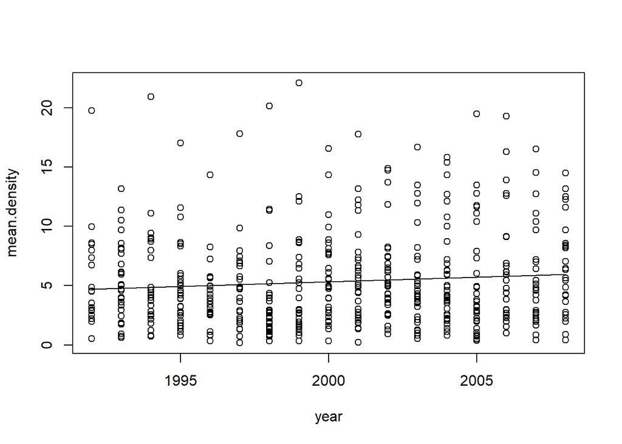

```r
with(subset(hares, landuse == "arable"), plot(year, mean.density))
points(1992:2008, coef(dens6)[1] + coef(dens6)[2]*1:17, type = "l")
```

```r
dens7 <- lm(mean.density ~ yearPost + I(yearPost*yearPost), data = hares.arable)
summary(dens7)
```

```
##
## Call:
## lm(formula = mean.density ~ yearPost + I(yearPost * yearPost),
##     data = hares.arable)
##
## Residuals:
##    Min     1Q Median     3Q    Max
## -5.999 -2.920 -1.031  1.819 17.097
##
## Coefficients:
##                        Estimate Std. Error t value Pr(>|t|)
## (Intercept)             5.27870    0.66299   7.962 1.21e-14 ***
## yearPost               -0.12516    0.16569  -0.755    0.450
## I(yearPost * yearPost)  0.01123    0.00891   1.260    0.208
## ---
## Signif. codes:  0 '***' 0.001 '**' 0.01 '*' 0.05 '.' 0.1 ' ' 1
##
## Residual standard error: 4.045 on 486 degrees of freedom
##   (191 observations deleted due to missingness)
## Multiple R-squared:  0.0115, Adjusted R-squared:  0.007433
## F-statistic: 2.827 on 2 and 486 DF,  p-value: 0.06015
```

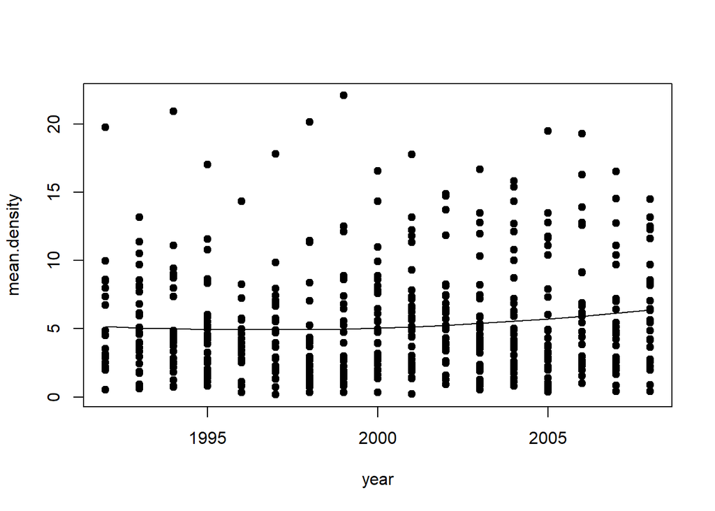

```r
with(hares.arable, plot(year, mean.density, pch = 19))
points(1992:2008, coef(dens7)[1] + coef(dens7)[2]*1:17 + coef(dens7)[3]*1:17*1:17, type = "l")
```

Note that we need to use the function *I()* for the quadratic term, which treats the variable “as is” rather than an interaction between two variables (as seen in the two-way ANOVA with an interaction).

**Practice example 2:** Using the built-in “ToothGrowth” R dataset, run linear regression to determine whether tooth growth changes linearly with vitamin C dosage.

```r
tg1 <- lm(len ~ dose, data = ToothGrowth)
```

#### ANCOVA

Here, we are running an analysis of covariance (ANCOVA) to evaluate the interactive effects of landuse and year on mean density of brown hares.

```r
dens8 <- lm(mean.density ~ yearPost*landuse, data = hares)
summary(dens8)
```

```
##
## Call:
## lm(formula = mean.density ~ yearPost * landuse, data = hares)
##
## Residuals:
##     Min      1Q  Median      3Q     Max
## -5.5404 -2.5285 -0.8794  1.5791 16.8569
##
## Coefficients:
##                       Estimate Std. Error t value Pr(>|t|)
## (Intercept)            4.61298    0.36480  12.645   <2e-16 ***
## yearPost               0.07790    0.03517   2.215   0.0271 *
## landusegrass          -0.68321    0.69953  -0.977   0.3291
## yearPost:landusegrass -0.15868    0.06791  -2.337   0.0197 *
## ---
## Signif. codes:  0 '***' 0.001 '**' 0.01 '*' 0.05 '.' 0.1 ' ' 1
##
## Residual standard error: 3.684 on 673 degrees of freedom
##   (275 observations deleted due to missingness)
## Multiple R-squared:  0.07275,    Adjusted R-squared:  0.06862
## F-statistic:  17.6 on 3 and 673 DF,  p-value: 5.205e-11
```

**Practice example 3:** From the infected individuals only, run an ANCOVA evaluating the interactive effects of sex and kidney fat index (KFI) on the estimated number of *Elaphostrongylus cervi* parasites.

This example uses epidemiological data from Vicente et al. (2006) that took observations on wild boar and red deer reared on a number of estates in Spain. Here, the dataset contains information on the red deer only. Observations on red deer were taken at different farms, months, year (0-5 are 2000-2005, 99 is 1999), and sexes (1 - Male, 2 - Female). For each observation, the length of the animal (LCT, length of head-body), kidney-fat index (KFI), the number of *Elaphostrongylus cervi* parasites (Ecervi), and the presence (0, 1) of Tuberculosis were taken. These data are used in examples from the [Zuur book](https://highstat.com/index.php/a-beginner-s-guide-to-r).

```r
deer <- read.table(here::here("Session 2", "Data", "Deer.txt"), header = T)

ec1 <- lm(Ecervi ~ KFI*Sex, data = subset(deer, Ecervi > 0))
```

#### Assumptions of normality

Before continuing with this statistical distribution, we always want to test for the assumptions of normality on our response variable. A linear regression has four assumptions:

1. *Linearity of the data:* linear relationship between *x* and *y*. (residuals vs fitted values)
2. *Normality of residuals:* residual errors are normally-distributed. (QQ plot)
3. *Homogeneity of residuals variance (i.e., homoscedasicity):* constant variance of the residuals. (scale-location plot)
4. *Independence of residuals error terms:* depends on what may be dependent on your residuals.

We can test for relevant assumptions using diagnostic plots:

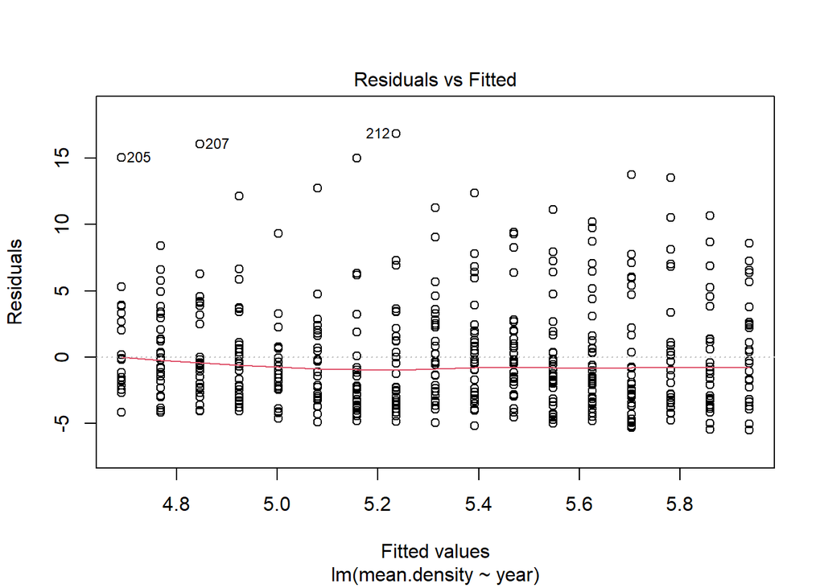

```r
dens6 <- lm(mean.density ~ year, data = hares.arable)

plot(dens6, 1) # Residuals vs fitted - red line is flat meaning linear relationsip
```

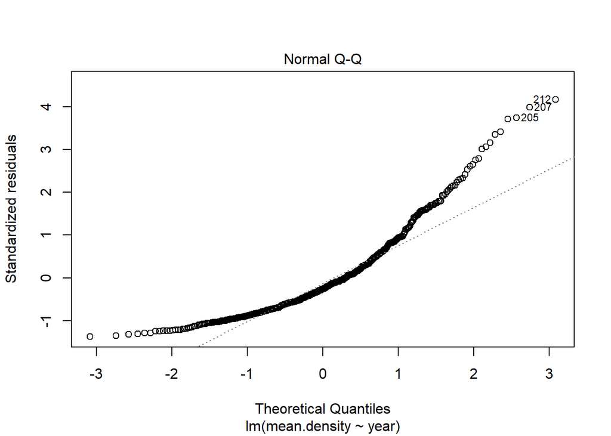

```r
plot(dens6, 2) # QQ plot - examine whether residuals are normally-distributed
```

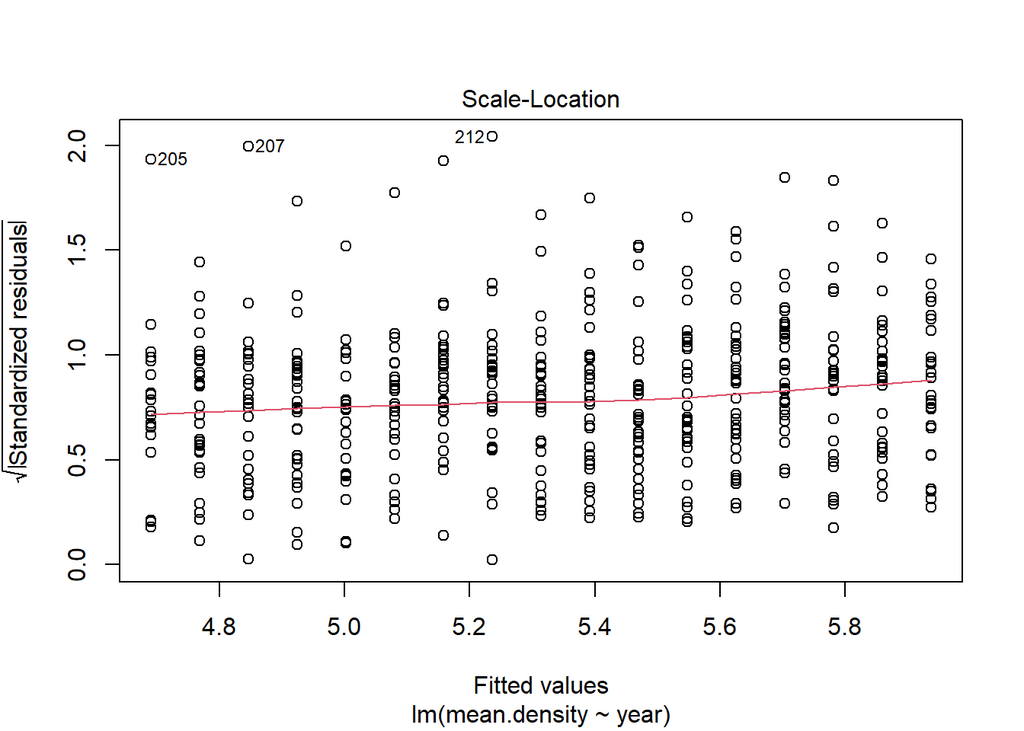

```r
plot(dens6, 3) # Scale-location - homogeneity of variance of residuals (homoscedasicity) if horizontal line with equal spread
```

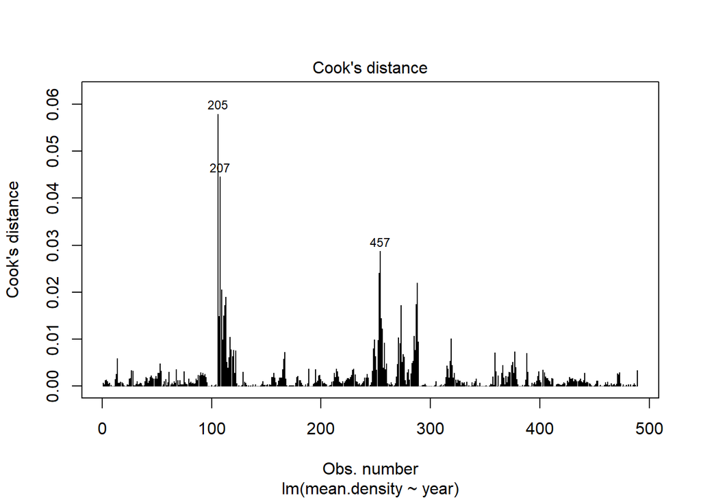

```r
plot(dens6, 4) # Cook's distance - identify extreme values and their obs. number
```